# Tutorial: Mapping localities in R with Lambert projection

D. Dols-Serrate

2025-07-29

# Basic requirements

- `R 4.1.0` or beyond. This tutorial was run on `R 4.5.1`.
- Preferably, at least one finger (optional).

# Introduction

This document provides a step-by-step tutorial for creating a high-quality map of sampled localities in Europe (although it could be anywhere) using R and the `ggplot2` package. We will start with raw latitude and longitude coordinates, project them onto a proper cartographic projection (Lambert Azimuthal Equal-Area), and customize the final map with colors, shapes, labels, and other cartographic elements. If everything runs smoothly, the expected result should look like the example below.

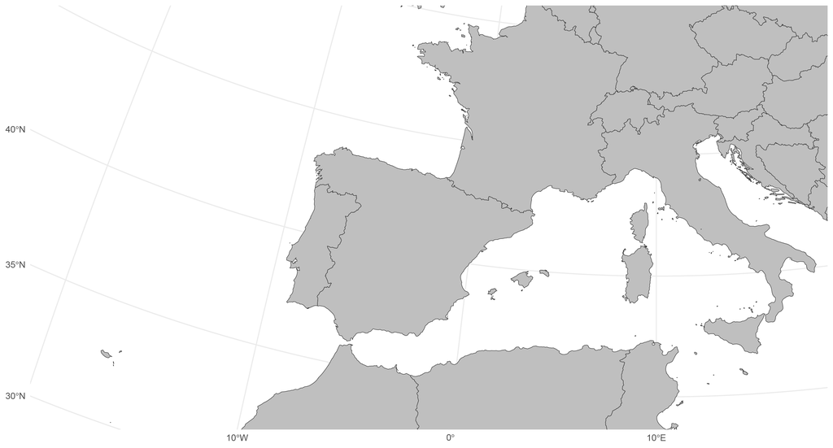

**Fig. 1.** Example of a map obtained with the methodology explained in this tutorial

The workflow is based on modern R spatial packages (`sf`, `rnaturalearth`, `ggrepel`) which provide a powerful and coherent system for spatial analysis and visualization. Feel free to make any changes and/or improvements on the code.

# Step 1: Loading Required R Packages

The first step in any R script is to load the necessary “libraries” or “packages” that contain the functions we need. We use the `library()` command for this. If you are running this for the first time, you may need to install these packages.

**To Install (run this in your R console *once*):**

`install.packages(c("sf", "ggplot2", "rnaturalearth", "ggrepel", "ggspatial"))`

```r
# Load the libraries for this session
library(sf)            # The modern framework for handling spatial data
library(ggplot2)       # The core package for creating all plots
library(rnaturalearth) # A great source for high-quality, free background map data
library(ggrepel)       # For adding non-overlapping text labels
library(ggspatial)     # For adding map elements like scale bars and north arrows
```

If problems arise when installing `rnaturalearth`, then try the following steps:

1. `install.packages("devtools", repos = "https://cloud.r-project.org/")` - Facilitates installation of R packages from github and other repositories
2. `library(devtools)`
3. `devtools::install_github("ropensci/rnaturalearthhires")` - Installs the troubling package from github repository

# Step 2: Preparing the Locality and Map Data

Next, we need to prepare our two main sources of data:

1. **The locality data:** Our list of sampling points, including their coordinates and metadata.
2. **The background map:** A map of the world that will serve as the canvas for our points.

### 2.1: Defining the Locality Data

In this tutorial we will build the `data.frame` from scratch, but alternatively we could always resort to build it somewhere else (e.g., `Excel`, `LibreOffice`, etc.) or obtain it from a database, and then load it using the following piece of code:

- `localities_df <- data.table::fread("my_localities.csv")`

or alternatively:

- `localities_df <- read.csv("my_localities.csv")`

When loading the data from a Comma-Separated Values (CSV) file, it is best to ensure it is saved in the same directory as this R Markdown document. We use the `fread()` function from the `data.table` package because it is fast and robust.

We start by creating a standard R `data.frame` with our longitude, latitude, and metadata. In this case, we will label each locality numerically from 1 to *n* (`label =` variable) and will add information concerning the species found in each location (`Data =` variable). If you are building your `data.frame` directly in R make sure that the order in which the localities and the metadata are entered in their pertinent vectors (the `c(...)` thingy) is the same. We then will convert this `data.frame` into a special `sf` (simple features) spatial object. This tells R which columns represent coordinates and what their initial Coordinate Reference System (CRS) is. We use `crs = 4326`, which is the standard code for WGS84 latitude/longitude.

If you opted for building the `data.frame` in R, the following can be used as a rough example of how you could do it.

```r
example_df <- data.frame(
  lon = c(9.11, 15.13, 11.46, 18.12, 10.04),      # Longitudinal coordinates
  lat = c(33.08, 39.96, 32.03, 35.86, 37.76),     # Latitudinal coordinates
  label = as.character(1:5),                      # Locality numbers or names. The later as in 'label = c("A", "B", "C" ...)
  Data = c("Sp.A","Sp.A","Sp.C","Sp.B","Sp.A")    # Add as many metadata columns as your data require. Here, data regarding the species affiliation is being added
)

# Convert the data frame into an 'sf' spatial object
example_sf_with_data <- st_as_sf(example_df, coords = c("lon", "lat"), crs = 4326)
```

### 2.2: Fetching the Background Map

For the sake of this tutorial, we will work with occurrence data of several allochthonous species. Hence, we will start by creating random points within the borders of the European continent. We will use the `rnaturalearth` package to get high-quality country outlines. We specify `returnclass = "sf"` to ensure the map data is in the same format as our locality points.

```r
# --- A. Set the number of random locations you want to generate ---
num_locations <- 35 # You can change this number to whatever you need

# --- B. Get high-resolution country outlines for the European continent ---
# We use rnaturalearth to get country data, then filter for Europe

europe_map <- ne_countries(scale = "large", continent = "Europe", returnclass = "sf")

# To sample from the entire landmass, we merge all individual country polygons
# into a single, unified shape.
europe_landmass <- st_union(europe_map)

# --- C. Generate random points constrained *within* the European landmass shape ---
# The st_sample function is perfect for this task.

random_points_sf <- st_sample(europe_landmass, size = num_locations, type = "random")

# --- D. Extract the longitude and latitude coordinates from the random points ---
# st_coordinates gives us a matrix of X (longitude) and Y (latitude) values
random_coords <- st_coordinates(random_points_sf)

# --- E. Create the final data frame in the same format as the example_df ---
# This is now your primary data frame for plotting.
random_european_locations_df <- data.frame(
  lon = random_coords[, "X"],
  lat = random_coords[, "Y"],
  # We'll add some placeholder metadata so the rest of the script works
  label = as.character(1:num_locations),
  Data = sample(c("Achamo torchicum", "Kimori treeckoi", "Mizugorou mudkipus"), size = num_locations, replace = TRUE)
)

# Convert the data frame into a proper 'sf' object.
random_points_sf_with_data <- st_as_sf(random_european_locations_df,
                                       coords = c("lon", "lat"),
                                       crs = 4326)

# You can inspect the first few rows to see the result
head(random_points_sf_with_data)
```

```
## Simple feature collection with 6 features and 2 fields
## Geometry type: POINT
## Dimension:     XY
## Bounding box:  xmin: 3.485887 ymin: 42.92772 xmax: 129.6329 ymax: 69.04127
## Geodetic CRS:  WGS 84
##   label               Data                  geometry
## 1     1 Mizugorou mudkipus POINT (52.44044 63.73157)
## 2     2    Kimori treeckoi POINT (43.12601 45.03691)
## 3     3    Kimori treeckoi POINT (99.15229 69.04127)
## 4     4 Mizugorou mudkipus POINT (129.6329 52.30794)
## 5     5   Achamo torchicum POINT (45.70339 42.92772)
## 6     6 Mizugorou mudkipus POINT (3.485887 48.05314)
```

Needless to say, `rnaturalearth` has other options and if wanted to keep it simple we could always get the outlines of the ‘whole world’ and then crop to the desired resolution (keep reading).

```r
# Get high-resolution country outlines
world_map <- ne_countries(scale = "large", returnclass = "sf")
```

# Step 3: Defining the Map Projection and Viewport

A crucial step in creating a true map is projecting our spherical globe data onto a flat 2D surface. We will use the **Lambert Azimuthal Equal-Area (LAEA)** projection, which is well-suited for Europe (`EPSG:3035`). We also define the rectangular area (the “bounding box”) we want our final map to show, using standard latitude/longitude coordinates. Whenever you want to adjust the limits of your map just change the values for `xmin`, `ymin`, `xmax`, and `ymax`. In this case, we chose values to crop Europe and a little bit of its surroundings.

```r
# Define the Lambert projection we want to use for the final map
crs_lambert <- "EPSG:3035"

# Define the bounding box for our final map in Lat/Lon coordinates
map_bounds_latlon <- st_bbox(c(xmin = -15.3, ymin = 30.3, xmax = 50.3, ymax = 80.5), crs = 4326)
```

# Step 4: Building the Map with `ggplot2`

Now we will build our map layer by layer using `ggplot2`. This “grammar of graphics” approach makes it easy to build up complex plots.

### Explanation of the Layers:

1. **`geom_sf(data = world_map, ...)`**: The base layer, drawing the countries.
2. **`geom_sf(data = random_points_sf, ...)`**: Draws the locality points. Here, we map the **color** and **shape** aesthetics to our `Data` column.
3. **`geom_text_repel(...)`**: Adds the numerical labels near each point, cleverly repositioning them to avoid overlap.
4. **`scale_color_manual()` & `scale_shape_manual()`**: These give us full control over which colors and shapes are used for each category in our data.
5. **`coord_sf(...)`**: This is the engine of our map. It reprojects all data to our target Lambert CRS and then zooms the view to our predefined bounding box.
6. **`annotation_scale()`**: Adds a cartographically correct scale bar.
7. **`theme()`**: Fine-tunes the visual appearance of non-data elements like the legend.

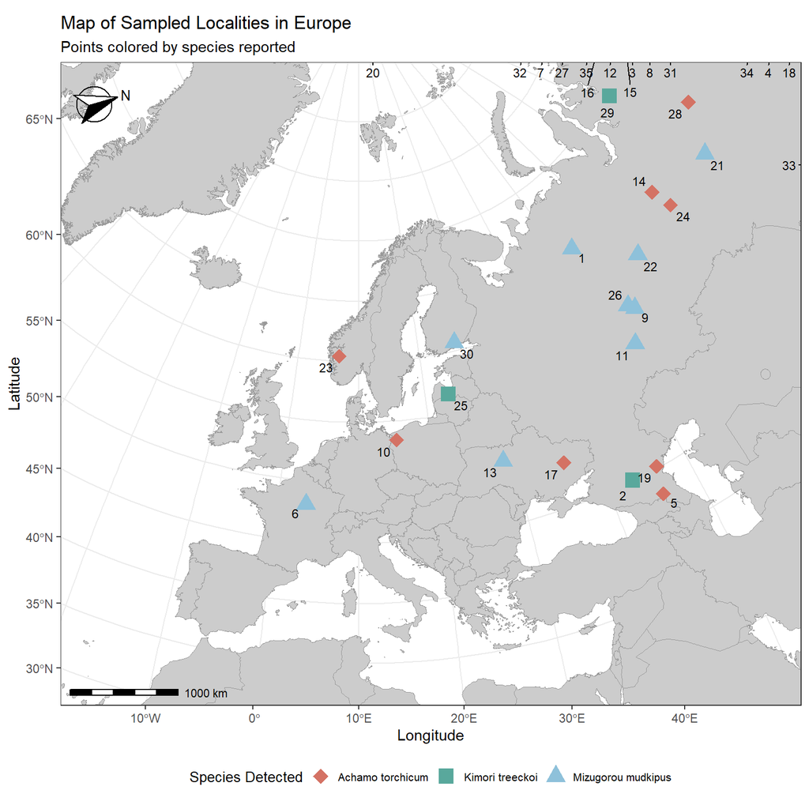

```r
# The main ggplot call to build the map
ggplot() +
  # Layer 1: The background map
  geom_sf(data = world_map, fill = "gray80",     # We define the color of inland areas
          color = "gray60") +                    # We define the color of the borders

  # Layer 2: European points with aesthetics mapped to the 'Data' column
  geom_sf(
    data = random_points_sf_with_data,
    aes(color = Data, shape = Data),
    size = 4,
    stroke = 1.5
  ) +

  # Layer 3: Add labels to the European points
  geom_text_repel(
    data = random_points_sf_with_data,
    aes(geometry = geometry, label = label), # Note we use the 'label' column here
    stat = "sf_coordinates",
    size = 3,
    nudge_y = -12000    # Nudge labels down. When multiple localities are clumped
    ) +                 # this variable will control how far the labels should
                        # be placed in the map to avoid clumping the text

  # --- MANUAL SCALES for better control over appearance ---
  scale_color_manual(                # We select the colors to be used in Layer 2
    name = "Species Detected",
    values = c("Kimori treeckoi" = "#59a89c",
               "Mizugorou mudkipus" = "#8ec1da",
               "Achamo torchicum" = "#d47264")
  ) +
  scale_shape_manual(                # We select the shapes to be used in Layer
                                     #2. There are 25 basic shapes availabl in R.
    name = "Species Detected",
    values = c("Kimori treeckoi" = 15,             # Square
               "Mizugorou mudkipus" = 17,        # Triangle
               "Achamo torchicum" = 18             # Tiny rhombus
               )
  ) +

  # Add ticks every 10 degrees for the X-axis (Longitude)
  scale_x_continuous(breaks = seq(from = -40, to = 80, by = 10)) +

  # Add ticks every 5 degrees for the Y-axis (Latitude)
  scale_y_continuous(breaks = seq(from = 30, to = 80, by = 5)) +

  # Layer 4: Set the projection and zoom
  coord_sf(
    crs = crs_lambert,
    xlim = st_bbox(st_transform(st_as_sfc(map_bounds_latlon), crs_lambert))[c("xmin", "xmax")],
    ylim = st_bbox(st_transform(st_as_sfc(map_bounds_latlon), crs_lambert))[c("ymin", "ymax")]
  ) +

  # Layer 4.1: Plain representation without Lambert projection
  # coord_sf(
  #  xlim = map_bounds_latlon[c("xmin", "xmax")],
  #  ylim = map_bounds_latlon[c("ymin", "ymax")],
  #  expand = FALSE # Keep this to prevent extra padding
  # ) +

  # Layer 5: Add map aesthetics - scale bar
  annotation_scale(
    location = "bl",            # 'bl' for bottom-left location of the bar. For
                                # 'top' locations use 't', e.g. 'tl' - top-left
    width_hint = 0.25,          # Adjust bar to occupy n% of the map width
    height = unit(0.15, "cm"),  # Adjust height of the bar
    text_cex = 0.7              # Adjust size of text in the scale bar
  ) +

   # Layer 5.1: Add map aesthetics - north arrow

  annotation_north_arrow(
    location = "tl",                          # 'tl' places it in the top-left corner
    which_north = "true",                     # Ensures it points to true north
    style = north_arrow_fancy_orienteering    # Chooses a specific visual style
  ) +

  # --- CONTROL LEGEND SYMBOL SIZE ---
  guides(color = guide_legend(override.aes = list(
    size = 4                    # Controls the size of shapes in the legend
  ))) +

  # Layer 6: Final theme and labels
  labs(
    title = "Map of Sampled Localities in Europe",         # All of this is quite self-explanatory
    subtitle = "Points colored by species reported",
    x = "Longitude",
    y = "Latitude"
  ) +
  theme_bw() +
  theme(
    legend.position = "bottom",                 # Controls where to place the legend
    legend.title = element_text(size = 10),
    legend.text = element_text(size = 8),
    legend.key.size = unit(0.5, "cm"),
    legend.key.spacing.x = unit(0.2, "cm")
  )
```

In case you are only interested in a map without any localities represented in it, simply comment the lines of code comprised within `Layers 2 & 3`. Additionally, if you prefer a map without a projection, substitute in the code `Layer 4` for the commented `Layer 4.1`.

# Final Remarks

The spirit of this tutorial is to facilitate the creation of map figures for your research . Whether you are preparing a figure for a publication or simply interested in visualizing spatial distribution data of species. Needless to say, there are plenty of maps out there and each one serves a purpose. However, this one will come in handy in most cases, especially in the field of Biology. And last but not least, Free Palestine.